# STSCI 5065 - Homework 4

Harry Lu

dl947

# Problem Set 1

[60 pts] You are given a set of two text files of New York Stock Exchange (NYSE) data, `NYSE_daily_prices.csv` and `NYSE_dividends.csv`. You are required to create some Pig relations based on the text files, and then do some analysis of the data using Pig scripts.

## A

[6 pts] Download the two data files from the course website to a local OS directory. Create an HDFS directory, `HW4`, right below the CentOS root. Use the Files View in Ambari to upload the two data files into `HW4`. Display a screenshot (in Ambari) showing all these files in the `/HW4` (your screenshot should show this directory name).

```
[root@sandbox ~]# hadoop fs -mkdir /HW4
```

[figure not shown]

## B

[14 pts] Create two relations **`stock_prices`** and **`stock_dividends`**.

The **`stock_prices`** relation contains columns in the following order: `exchng`, `symbol`, `ymd`, `price_open`, `price_high`, `price_low`, `price_close`, `volume`, and `price_adj_close`. The data types of `exchng`, `symbol` and `ymd` are **chararray** (same in the **`stock_dividends`** relation), `volume`’s data type is **int**, and other columns are of **double** data type.

The **`stock_dividends`** contains the columns in the following order: `exchng`, `symbol`, `ymd`, and `dividend`. The data type of `dividend` is **double**.

Dump these two relations, and attach screenshots to show your results (first 10 rows only).

```
stock_prices = LOAD '/HW4/NYSE_daily_prices.csv'
                USING PigStorage(',')
                AS (exchng: chararray,
                    symbol: chararray,
                    ymd: chararray,
                    price_open: double,
                    price_high: double,
                    price_low: double,
                    price_close: double,
                    volume: int,
                    price_adj_close: double);
stock_prices_10 = LIMIT stock_prices 10;
DUMP stock_prices_10;
```

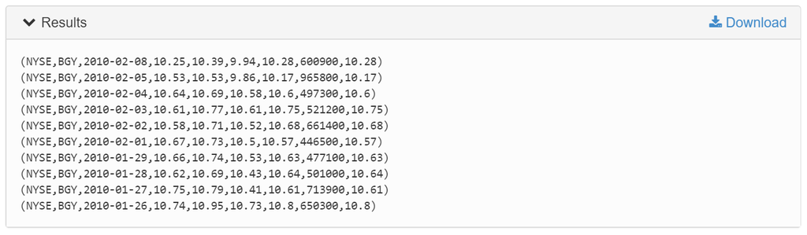

```
stock_dividends = LOAD '/HW4/NYSE_dividends.csv'
                  USING PigStorage(',')
                  AS (exchng: chararray,
                      symbol: chararray,
                      ymd: chararray,
                      dividend: double);
stock_dividends_10 = LIMIT stock_dividends 10;
DUMP stock_dividends_10;
```

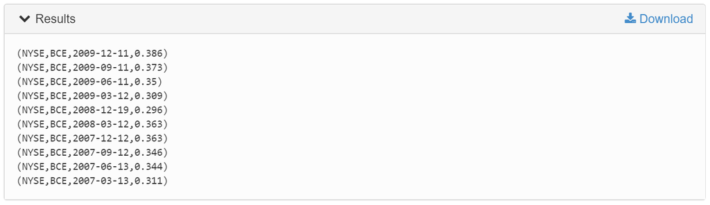

## C

[7 pts] Use the **`stock_prices`** relation to find out the number of entries of each stock symbol. You are only required to show two screenshots of the first 10 rows and the last 10 rows of your result (sorted by `symbol`).

```
stock_prices = LOAD '/HW4/NYSE_daily_prices.csv'
                USING PigStorage(',')
                AS (exchng: chararray,
                    symbol: chararray,
                    ymd: chararray,
                    price_open: double,
                    price_high: double,
                    price_low: double,
                    price_close: double,
                    volume: int,
                    price_adj_close: double);
grpd = group stock_prices by symbol;
symbolcnt = foreach grpd {
  sym = stock_prices.symbol;
  generate group, COUNT(sym);
};
dump symbolcnt;
```

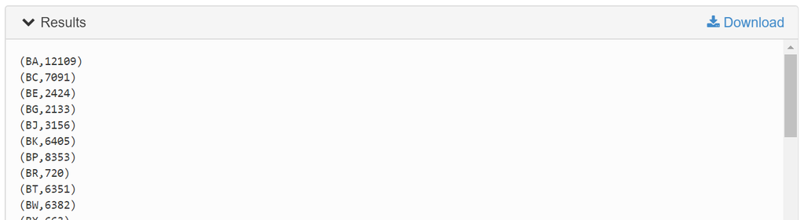

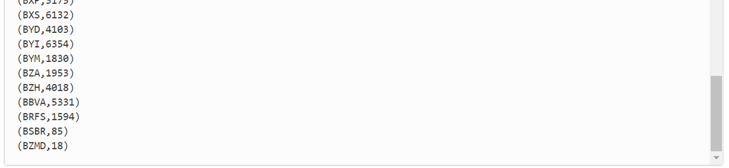

## D

[6 pts] Calculate the average stock opening price of each stock symbol rounded to 4 decimal points (same below). Use an alias, `ap`, for the average price column. Attach a screenshot of the last ten rows of the output.

```
stock_prices = LOAD '/HW4/NYSE_daily_prices.csv'
                USING PigStorage(',')
                AS (exchng: chararray,
                    symbol: chararray,
                    ymd: chararray,
                    price_open: double,
                    price_high: double,
                    price_low: double,
                    price_close: double,
                    volume: int,
                    price_adj_close: double);
grpd = group stock_prices by symbol;
ap = foreach grpd generate group, ROUND_TO(AVG(stock_prices.price_open),4);
dump ap;
```

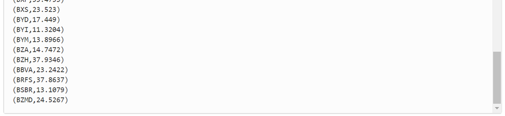

## E

[10 pts] Find out the stock symbols that have the highest and lowest average opening prices, respectively. You are required to use the relation created in step D. Attach the screenshots of the query results. Each of your final results should only contain two columns, i.e., the symbol and the highest or lowest average opening price.

```
stock_prices = LOAD '/HW4/NYSE_daily_prices.csv'
                USING PigStorage(',')
                AS (exchng: chararray,
                    symbol: chararray,
                    ymd: chararray,
                    price_open: double,
                    price_high: double,
                    price_low: double,
                    price_close: double,
                    volume: int,
                    price_adj_close: double);
grpd = group stock_prices by symbol;
avgopen = foreach grpd generate group, ROUND_TO(AVG(stock_prices.price_open),4) as ap;
sorted = order avgopen by ap desc;
top1 = limit sorted 1;
dump top1;
```

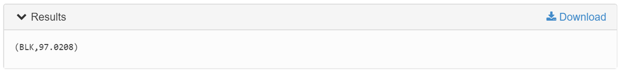

```
stock_prices = LOAD '/HW4/NYSE_daily_prices.csv'
                USING PigStorage(',')
                AS (exchng: chararray,
                    symbol: chararray,
                    ymd: chararray,
                    price_open: double,
                    price_high: double,
                    price_low: double,
                    price_close: double,
                    volume: int,
                    price_adj_close: double);
grpd = group stock_prices by symbol;
avgopen = foreach grpd generate group, ROUND_TO(AVG(stock_prices.price_open),4) as ap;
sorted_reverse = order avgopen by ap;
bottom1 = limit sorted_reverse 1;
dump bottom1;
```

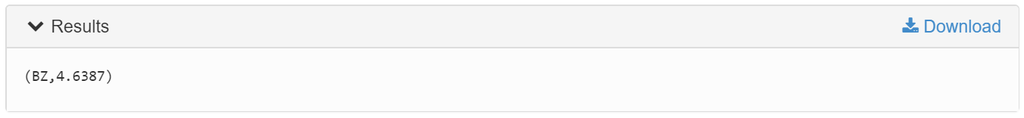

## F

[10 pts] Create a relation called `stock_div` from `NYSE_dividends.csv`. Find out the stock symbol that has the highest dividends. What are the date and the opening price of that stock when that happened? Attach the screenshots of your results.

```
stock_div = LOAD '/HW4/NYSE_dividends.csv'
              USING PigStorage(',')
              AS (exchng: chararray,
                  symbol: chararray,
                  ymd: chararray,
                  dividend: double);
A = FOREACH stock_div GENERATE symbol, ymd, dividend;
B = ORDER A by dividend DESC;
C = LIMIT B 1;
DUMP C;
```

Dividend:

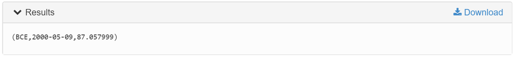

```
stock_prices = LOAD '/HW4/NYSE_daily_prices.csv'
                USING PigStorage(',')
                AS (exchng: chararray,
                    symbol: chararray,
                    ymd: chararray,
                    price_open: double,
                    price_high: double,
                    price_low: double,
                    price_close: double,
                    volume: int,
                    price_adj_close: double);
stock_div = LOAD '/HW4/NYSE_dividends.csv'
              USING PigStorage(',')
              AS (exchng: chararray,
                  symbol: chararray,
                  ymd: chararray,
                  dividend: double);
A = FOREACH stock_div GENERATE symbol, ymd, dividend;
B = ORDER A by dividend DESC;
C = LIMIT B 1;
sp = FOREACH stock_prices GENERATE symbol, ymd, price_open;
D = FILTER sp BY (ymd==C.ymd AND symbol==C.symbol);
DUMP D;
```

Open Price:

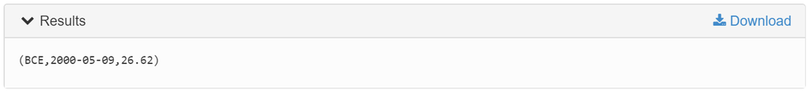

# Problem Set 2

[40 pts] You are given a text file (`flight12.csv`) of flight delays and are required to do the following.

## A

[8 pts] Create a relation called **`alldata`** based on the `flight12.csv`.

You use the following column names for the data fields in each record: `YEAR`, `FL_DATE`, `UNIQUE_CARRIER`, `CARRIER`, `FL_NUM`, `ORIGIN_AIRPORT_ID`, `ORIGIN`, `ORIGIN_CITY_NAME`, `ORIGIN_STATE_ABR`, `DEST_AIRPORT_ID`, `DEST`, `DEST_CITY_NAME`, `DEST_STATE_ABR`, `DEP_DELAY_NEW`, `ARR_DELAY`, `ARR_DELAY_NEW`, `CARRIER_DELAY`, `WEATHER_DELAY`, `NAS_DELAY`, `SECURITY_DELAY`, and `LATE_AIRCRAFT_DELAY`. If a column name contains the word “DELAY”, assign the **float** data type. Leave all other columns the **default** data type.

Since the `flight12.csv` dataset contains a special data format (e.g., data values that contains a comma and that are enclosed in quotation marks), you will need to use a special loader function to load the data, which is `org.apache.pig.piggybank.storage.CSVExcelStorage()`.

Give a screenshot of the first ten rows of the **`alldata`** relation.

```
alldata = LOAD '/HW4/flight12.csv'
            USING org.apache.pig.piggybank.storage.CSVExcelStorage()
            AS (YEAR,
                FL_DATE,
                UNIQUE_CARRIER,
                CARRIER,
                FL_NUM,
                ORIGIN_AIRPORT_ID,
                ORIGIN,
                ORIGIN_CITY_NAME,
                ORIGIN_STATE_ABR,
                DEST_AIRPORT_ID,
                DEST,
                DEST_CITY_NAME,
                DEST_STATE_ABR,
                DEP_DELAY_NEW: float,
                ARR_DELAY: float,
                ARR_DELAY_NEW: float,
                CARRIER_DELAY: float,
                WEATHER_DELAY: float,
                NAS_DELAY: float,
                SECURITY_DELAY: float,
                LATE_AIRCRAFT_DELAY: float
                );
A = LIMIT alldata 10;
DUMP A;
```

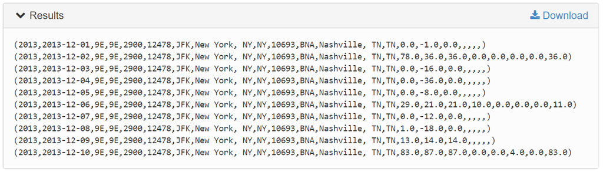

## B

[2 pts] Create a relation, **`wanted_data`**, based on the **`alldata`** relation, which only contains the following columns: `FL_DATE`, `FL_NUM`, `CARRIER_DELAY`, `WEATHER_DELAY`, `NAS_DELAY`, `SECURITY_DELAY`, and `LATE_AIRCRAFT_DELAY`.

```
alldata = LOAD '/HW4/flight12.csv'
            USING org.apache.pig.piggybank.storage.CSVExcelStorage()
            AS (YEAR,
                FL_DATE,
                UNIQUE_CARRIER,
                CARRIER,
                FL_NUM,
                ORIGIN_AIRPORT_ID,
                ORIGIN,
                ORIGIN_CITY_NAME,
                ORIGIN_STATE_ABR,
                DEST_AIRPORT_ID,
                DEST,
                DEST_CITY_NAME,
                DEST_STATE_ABR,
                DEP_DELAY_NEW: float,
                ARR_DELAY: float,
                ARR_DELAY_NEW: float,
                CARRIER_DELAY: float,
                WEATHER_DELAY: float,
                NAS_DELAY: float,
                SECURITY_DELAY: float,
                LATE_AIRCRAFT_DELAY: float
                );
wanted_data = FOREACH alldata
              GENERATE FL_DATE,
                        FL_NUM,
                        CARRIER_DELAY,
                        WEATHER_DELAY,
                        NAS_DELAY,
                        SECURITY_DELAY,
                        LATE_AIRCRAFT_DELAY;
```

## C

[7 pts] Find out the longest delay of each category of delay based on the **`wanted_data`** relation. Attach a screenshot of your results.

```
alldata = LOAD '/HW4/flight12.csv'
            USING org.apache.pig.piggybank.storage.CSVExcelStorage()
            AS (YEAR,
                FL_DATE,
                UNIQUE_CARRIER,
                CARRIER,
                FL_NUM,
                ORIGIN_AIRPORT_ID,
                ORIGIN,
                ORIGIN_CITY_NAME,
                ORIGIN_STATE_ABR,
                DEST_AIRPORT_ID,
                DEST,
                DEST_CITY_NAME,
                DEST_STATE_ABR,
                DEP_DELAY_NEW: float,
                ARR_DELAY: float,
                ARR_DELAY_NEW: float,
                CARRIER_DELAY: float,
                WEATHER_DELAY: float,
                NAS_DELAY: float,
                SECURITY_DELAY: float,
                LATE_AIRCRAFT_DELAY: float
                );
wanted_data = FOREACH alldata
              GENERATE FL_DATE,
                        FL_NUM,
                        CARRIER_DELAY,
                        WEATHER_DELAY,
                        NAS_DELAY,
                        SECURITY_DELAY,
                        LATE_AIRCRAFT_DELAY;
A = GROUP wanted_data ALL;
B = FOREACH A GENERATE
      MAX(wanted_data.CARRIER_DELAY),
      MAX(wanted_data.WEATHER_DELAY),
      MAX(wanted_data.NAS_DELAY),
      MAX(wanted_data.SECURITY_DELAY),
      MAX(wanted_data.LATE_AIRCRAFT_DELAY);
DUMP B;
```

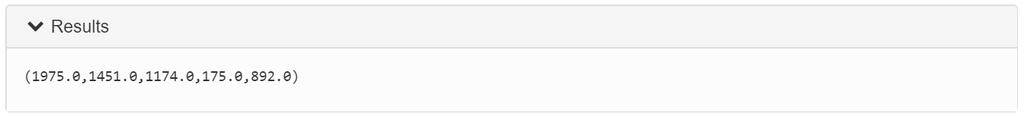

## D

[8 pts] What are the average delays (round to 2 decimal points) of the following delay categories: `CARRIER_DELAY`, `WEATHER_DELAY`, `NAS_DELAY`, `SECURITY_DELAY`, and `LATE_AIRCRAFT_DELAY`?

```
alldata = LOAD '/HW4/flight12.csv'
            USING org.apache.pig.piggybank.storage.CSVExcelStorage()
            AS (YEAR,
                FL_DATE,
                UNIQUE_CARRIER,
                CARRIER,
                FL_NUM,
                ORIGIN_AIRPORT_ID,
                ORIGIN,
                ORIGIN_CITY_NAME,
                ORIGIN_STATE_ABR,
                DEST_AIRPORT_ID,
                DEST,
                DEST_CITY_NAME,
                DEST_STATE_ABR,
                DEP_DELAY_NEW: float,
                ARR_DELAY: float,
                ARR_DELAY_NEW: float,
                CARRIER_DELAY: float,
                WEATHER_DELAY: float,
                NAS_DELAY: float,
                SECURITY_DELAY: float,
                LATE_AIRCRAFT_DELAY: float
                );
wanted_data = FOREACH alldata
              GENERATE FL_DATE,
                        FL_NUM,
                        CARRIER_DELAY,
                        WEATHER_DELAY,
                        NAS_DELAY,
                        SECURITY_DELAY,
                        LATE_AIRCRAFT_DELAY;
A = GROUP wanted_data ALL;
B = FOREACH A GENERATE
      ROUND_TO(AVG(wanted_data.CARRIER_DELAY), 2),
      ROUND_TO(AVG(wanted_data.WEATHER_DELAY), 2),
      ROUND_TO(AVG(wanted_data.NAS_DELAY), 2),
      ROUND_TO(AVG(wanted_data.SECURITY_DELAY), 2),
      ROUND_TO(AVG(wanted_data.LATE_AIRCRAFT_DELAY), 2);
DUMP B;
```

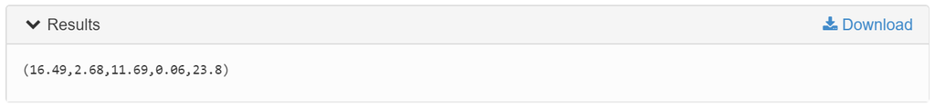

## E

[15 pts] Use Python to write a UDF named, `delay_udf.py`, to identify the most common and most uncommon delay categories based on the average delays in the `avg_result` relation obtained in Step D. If the highest and lowest average delays are x minutes (correspondent to `XX_DELAT`) and y minutes (correspondent to `YY_DELAY`) respectively, your Pig script must output the following language: “*The most common delay category is `XX_DELAY`, which has an average delay of `x` minutes, and the most uncommon delay category is `YY_DELAY`, which has an average delay of `y` minutes.*”

Submit a screenshot of your `delay_udf.py` file in the **vi** editor and a screenshot of your Pig script using the UDF. (Hint: you should use a tuple of tuples as the argument for the UDF.)

```python
@outputSchema("output_string:chararray")
def show(input_tuple):
    internal_tuple = ("CARRIER_DELAY","WEATHER_DELAY","NAS_DELAY","SECURITY_DELAY","LATE_AIRCRAFT_DELAY")
    max_value = max(input_tuple)
    min_value = min(input_tuple)
    max_index = 0
    min_index = 0
    for i in range(len(input_tuple)):
        if input_tuple[i] == max_value:
            max_index = i
    for i in range(len(input_tuple)):
        if input_tuple[i] == min_value:
            min_index = i
    highest_average_delay = internal_tuple[max_index]
    lowest_average_delay = internal_tuple[min_index]
    output_tuple = (highest_average_delay, max_value, lowest_average_delay, min_value)
    output_string = "The most common delay category is %s, which has an average delay of %s minutes, and the most uncommon delay category is %s, which has an average delay of %s minutes." % output_tuple
    return output_string
```

[figure not shown]

```
REGISTER '/HW4/delay_udf.py' USING jython AS udf;

alldata = LOAD '/HW4/flight12.csv'
            USING org.apache.pig.piggybank.storage.CSVExcelStorage()
            AS (YEAR,
                FL_DATE,
                UNIQUE_CARRIER,
                CARRIER,
                FL_NUM,
                ORIGIN_AIRPORT_ID,
                ORIGIN,
                ORIGIN_CITY_NAME,
                ORIGIN_STATE_ABR,
                DEST_AIRPORT_ID,
                DEST,
                DEST_CITY_NAME,
                DEST_STATE_ABR,
                DEP_DELAY_NEW: float,
                ARR_DELAY: float,
                ARR_DELAY_NEW: float,
                CARRIER_DELAY: float,
                WEATHER_DELAY: float,
                NAS_DELAY: float,
                SECURITY_DELAY: float,
                LATE_AIRCRAFT_DELAY: float
                );
wanted_data = FOREACH alldata
              GENERATE FL_DATE,
                        FL_NUM,
                        CARRIER_DELAY,
                        WEATHER_DELAY,
                        NAS_DELAY,
                        SECURITY_DELAY,
                        LATE_AIRCRAFT_DELAY;
A = GROUP wanted_data ALL;
avg_result = FOREACH A GENERATE
              ROUND_TO(AVG(wanted_data.CARRIER_DELAY), 2) as a,
              ROUND_TO(AVG(wanted_data.WEATHER_DELAY), 2) as b,
              ROUND_TO(AVG(wanted_data.NAS_DELAY), 2) as c,
              ROUND_TO(AVG(wanted_data.SECURITY_DELAY), 2) as d,
              ROUND_TO(AVG(wanted_data.LATE_AIRCRAFT_DELAY), 2) as e;
B = FOREACH avg_result GENERATE udf.show(TOTUPLE(a,b,c,d,e));
DUMP B;
```

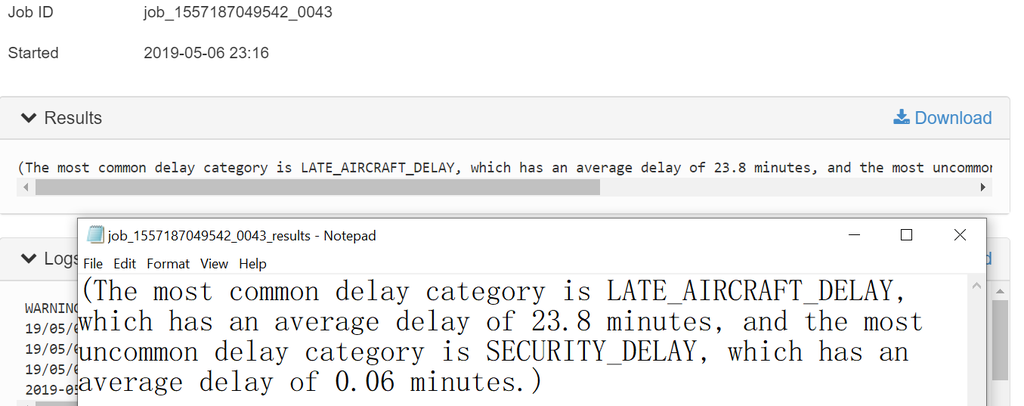